# Introduction to R

Jing Fang

# This lecture covers

- Welcome to R!
- Installing R
- Understanding the R language
- Running programs

# 1.1 Introduction to R

# Introduction to R

- Today’s data analysts need to be able to:
  - Access data from a wide range of sources
  - Merge the pieces of data together
  - Clean and annotate them
  - Analyze them with the latest methods
  - Present the finding in meaningful and graphically appealing ways
  - Incorporate the result into attractive reports that can be distributed to the public.

# Introduction to R

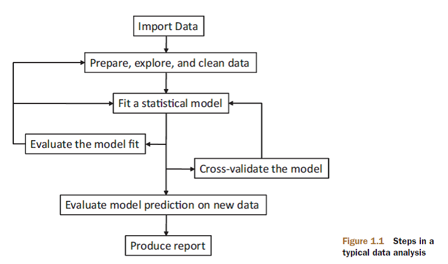

# What is R?

- R is a free software environment for statistical computing and graphics.
- R has become the world-wide language for statistics, predictive analytics, and data visualization.

# What can you do with R?

- Do calculations
- Perform statistic analysis
- Create graphics
- Write your own functions

# Why R?

- Technical advantages: free, open-source, available for all OSs
- Efficient functions and data structures for data analysis
- Powerful graphics
- Access to fast growing number of analysis packages

# Comparison to other software

- Stata: It can handle all kinds of econometrics research. Many packages available
- SAS: It is really good for big data set, but the grammar is really weird.
- Matlab: I could not compare it directly to R since it is mainly a mathematical and engineering software instead of a statistic one. The only problem may be the size.
- Others do not be very popular in economic field. SPSS may be good for management student; Eviews specializes more in time series analysis.
- And the most important factor: you need to pay for them.

# 1.2 Obtaining and installing R

# Obtaining and installing R

- Installation of binary versions is fairly straightforward: just go to [R website](http://www.r-project.org), pick the version corresponding to your OS, and follow the instructions provided in the corresponding readme file.
- You will not like the ugly R interface. I suggest the beautiful [Rstudio](http://www.rstudio.com/products/rstudio/)
- Base R is extended by means of packages, some of which are part of the default installtaion.
- Any question?

# 1.3 Working with R

# Working with R

- There is an important difference in philosophy between R and the most other econometrics packages.
- With many packages, an analysis will lead to a large amount of output containing info on estimation, model diagnostics, specification tests, etc.
- In R, an analysis is normally broken down into a series of steps. Intermediate results are stored in objects, with minimal output at each step.
- Instead, the objects are further manipulated to obtain the info required.

# Working with R

- R is a case-sensitive, interpreted language.
- Most functionality is provided through built-in and user-created functions.
- R uses both ‘<-’ and ‘=’ for assignments. ‘=’ is recommended
- Comments are preceded by the # symbol.

# Working with R

```r
x = rnorm(5)
x
```

```
## [1]  0.04105 -1.01723  0.98889 -0.42640  0.98397
```

# Getting started

- Suppose you are studying physical development and collected the ages and weights of 10 infants in their first year of life.

[output not shown]

- You are interested in the distribution of the weights and their relationship to age.

# Getting started

```r
age = c(1, 3, 5, 2, 11, 9, 3, 9, 12, 3)
weight = c(4.4, 5.3, 7.2, 5.2, 8.5, 7.3, 6, 10.4, 10.2, 6.1)
mean(weight)
```

```
## [1] 7.06
```

```r
sd(weight)
```

```
## [1] 2.077
```

```r
cor(age, weight)
```

```
## [1] 0.9076
```

# Getting started

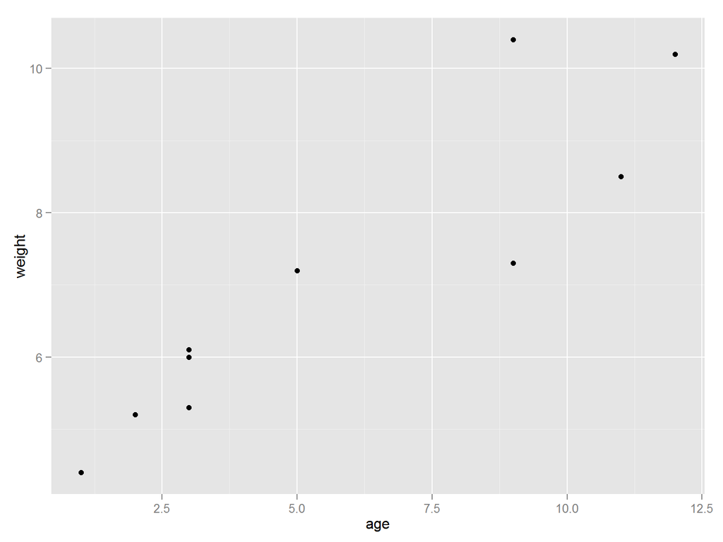

```r
library(ggplot2)
qplot(age, weight)
```

# Getting help

- The built-in help system provides details, references and examples of any function contained in a currently installed package.
- I think the other easy way is to google it. Never use baidu!
- `?foo`

# The workspace

- The workspace is your current R working environment and includes any user-defined objects.
- The current working directory is the directory R will read files from and save results to by default.
- Several useful functions:

```r
getwd()
setwd()
options()
save(objectlist, file = "myfile")
load("myfile")
```

# The workspace

```r
getwd()
setwd("c:/mydocument/project1")
options(digits = 4)
```

# 1.4 Packages

# Packages

- Packages are collections of R functions, data, and compiled code in a well-defined format.

  ```r
  install.packages()
  library()
  ```

# Packages

Common mistakes

- Using the wrong case: `help()`, `Help()`, `HELP()`
- Forgetting to use quote marks when they are needed: `install.packages("stringr")`
- Forgetting to include the parentheses in a function call: `help()`, `help`
- Using the \ in a pathname on windows:
  - `setwd("c:\myprogram")` #does not work
  - `setwd("c:/myprogram")`, or `setwd("c:\\myprogram")`
- Using a function from a package that is not loaded: `library()`

# 1.5 Using output as input—reusing results

# Using output as input—reusing results

- One of the most useful design features of R is that the output of analysis can easily be saved and used as input to additional analysis.
- Always remember to store the results in an object.

# Homework 1

- Install [R](http://www.r-project.org) and [Rstudio](http://www.rstudio.com/products/rstudio/).
- Install the following packages: `ggplot2`, `AER`
- List the functions and datasets available in these packages.
- Load the packages
- Read the description of the function `qplot` from `ggplot2`
- Run the example that comes with the functions